# [Portfolio] Sales Time Series 1

## SARIMAX

SARIMA + Exogenous Variable (Holidays)

Disclaimer: Using a daily frequency exogenous variable (such as holidays) on a monthly frequency time series is inappropriate. This was done for experimental purposes.

```python
# Load data
data = pd.read_csv('https://raw.githubusercontent.com/dsacademybr/Datasets/master/dataset6.csv')

# Setting column names to lowercase
data.columns = map(str.lower, data.columns)

# Substituting espaces and dashes in the column names by underscores
data.columns = data.columns.str.replace(" ", "_")
data.columns = data.columns.str.replace("-", "_")

# Splitting data by category
df_technology = data.loc[data['category'] == 'Technology']

# Aggregating sales by order date
ts_technology = df_technology.groupby('order_date')['sales'].sum().reset_index()

# Setting the date as index
ts_technology = ts_technology.set_index('order_date')

# Retrieving only sales data
sales_technology = ts_technology[['sales']]

# Changing index type
sales_technology.index = pd.to_datetime(sales_technology.index)

# Resampling data to a monthly frequency
# Done by setting the month as index and then calculating the mean of daily sales over the month
sales_technology_monthly_mean = sales_technology['sales'].resample('MS').mean()

# Train-Test Split
X = sales_technology_monthly_mean
train_size = int(len(X) * 0.75)
trainset, testset = X[0:train_size], X[train_size:]
```

Create dataframe with holidays

```python
# Create empty dataframe
festivities = pd.Series()
```

```python
# Retrieving all holidays in the US from 2014 to 2017
for i, festivity in holidays.US(years = [2014, 2015, 2016, 2017]).items():
    festivities[i] = festivity
```

```python
# Visualizing data
festivities.head(8)
```

```
2016-01-01                 New Year's Day
2016-01-18    Martin Luther King, Jr. Day
2016-02-15          Washington's Birthday
2016-05-30                   Memorial Day
2016-07-04               Independence Day
2016-09-05                      Labor Day
2016-10-10                   Columbus Day
2016-11-11                   Veterans Day
dtype: object
```

```python
# Type
type(festivities)
```

```
pandas.core.series.Series
```

```python
# Converting the series to dataframe
festivities_df = pd.DataFrame(festivities)
```

```python
# Type
type(festivities_df)
```

```
pandas.core.frame.DataFrame
```

```python
# Shape
festivities_df.shape
```

```
(44, 1)
```

```python
# Resetting index to change column names
festivities_df.reset_index(level = 0, inplace = True)
```

```python
# Ajusta o nome das colunas
festivities_df.columns = ['date_festivity', 'festivity']
```

```python
# Visualiza
festivities_df.head()
```

|  | date_festivity | festivity |
| --- | --- | --- |
| 0 | 2016-01-01 | New Year's Day |
| 1 | 2016-01-18 | Martin Luther King, Jr. Day |
| 2 | 2016-02-15 | Washington's Birthday |
| 3 | 2016-05-30 | Memorial Day |
| 4 | 2016-07-04 | Independence Day |

```python
# Data types
festivities_df.dtypes
```

```
date_festivity    object
festivity         object
dtype: object
```

```python
# Setting the date column as datetime type
festivities_df['date_festivity'] = pd.to_datetime(festivities_df['date_festivity'])
```

```python
# Data types
festivities_df.dtypes
```

```
date_festivity    datetime64[ns]
festivity                 object
dtype: object
```

```python
# Function to add holidays to the sales dataframe
def add_holiday(x):

    # Apply rule to set a dummy variable as 1 if it's holiday
    batch_df = festivities_df.apply(lambda y: 1 if (x['order_date'] == y['date_festivity']) else None, axis=1)

    ### For it to work properly with monthly data need to figure a way to make the function sum all holidays in a given month

    # Drop null values
    batch_df = batch_df.dropna(axis = 0, how = 'all')

    # If it's empty, fill with 0
    if batch_df.empty:
        batch_df = 0
    else:
        batch_df = batch_df.to_string(index = False)

    return batch_df
```

```python
# Confirming object type
type(sales_technology_monthly_mean)
```

```
pandas.core.series.Series
```

```python
# Convert series to dataframe
sales_technology_monthly_mean_df = pd.DataFrame(sales_technology_monthly_mean)
```

```python
# Confirm object type
type(sales_technology_monthly_mean_df)
```

```
pandas.core.frame.DataFrame
```

```python
# Reset index to rename columns
sales_technology_monthly_mean_df.reset_index(level = 0, inplace = True)
```

```python
# Rename columns
sales_technology_monthly_mean_df.columns = ['order_date', 'sales']
```

```python
# Checking
sales_technology_monthly_mean_df.head(3)
```

|  | order_date | sales |
| --- | --- | --- |
| 0 | 2014-01-01 | 449.041429 |
| 1 | 2014-02-01 | 229.787143 |
| 2 | 2014-03-01 | 2031.948375 |

```python
# Data types
sales_technology_monthly_mean_df.dtypes
```

```
order_date    datetime64[ns]
sales                float64
dtype: object
```

```python
# Applying the function on a newly created holiday column
sales_technology_monthly_mean_df['festivity'] = sales_technology_monthly_mean_df.apply(add_holiday, axis = 1)
```

```python
# Checking
sales_technology_monthly_mean_df.head(3)
```

|  | order_date | sales | festivity |
| --- | --- | --- | --- |
| 0 | 2014-01-01 | 449.041429 | 1.0 |
| 1 | 2014-02-01 | 229.787143 | 0 |
| 2 | 2014-03-01 | 2031.948375 | 0 |

```python
# Converting the holiday column to integer
sales_technology_monthly_mean_df['festivity'] = pd.to_numeric(sales_technology_monthly_mean_df['festivity'], downcast = 'integer')
```

```python
# Checking
sales_technology_monthly_mean_df.head(3)
```

|  | order_date | sales | festivity |
| --- | --- | --- | --- |
| 0 | 2014-01-01 | 449.041429 | 1 |
| 1 | 2014-02-01 | 229.787143 | 0 |
| 2 | 2014-03-01 | 2031.948375 | 0 |

```python
# Setting order_date as index
sales_technology_monthly_mean_df.set_index("order_date", inplace = True)
```

```python
# Checking
sales_technology_monthly_mean_df.head(3)
```

| order_date | sales | festivity |
| --- | --- | --- |
| 2014-01-01 | 449.041429 | 1 |
| 2014-02-01 | 229.787143 | 0 |
| 2014-03-01 | 2031.948375 | 0 |

```python
# Deleting the original series (of series type)
del sales_technology_monthly_mean
```

```python
# Recreating the original series (as dataframe)
sales_technology_monthly_mean = sales_technology_monthly_mean_df
```

```python
# Voilá
sales_technology_monthly_mean
```

| order_date | sales | festivity |
| --- | --- | --- |
| 2014-01-01 | 449.041429 | 1 |
| 2014-02-01 | 229.787143 | 0 |
| 2014-03-01 | 2031.948375 | 0 |
| 2014-04-01 | 613.028933 | 0 |
| 2014-05-01 | 564.698588 | 0 |
| 2014-06-01 | 766.905909 | 0 |
| 2014-07-01 | 533.608933 | 0 |
| 2014-08-01 | 708.435385 | 0 |
| 2014-09-01 | 2035.838133 | 1 |
| 2014-10-01 | 596.900900 | 0 |
| 2014-11-01 | 1208.056320 | 0 |
| 2014-12-01 | 1160.732889 | 0 |
| 2015-01-01 | 925.070800 | 1 |
| 2015-02-01 | 431.121250 | 0 |
| 2015-03-01 | 574.662333 | 0 |
| 2015-04-01 | 697.559500 | 0 |
| 2015-05-01 | 831.642857 | 0 |
| 2015-06-01 | 429.024400 | 0 |
| 2015-07-01 | 691.397733 | 0 |
| 2015-08-01 | 1108.902286 | 0 |
| 2015-09-01 | 950.856400 | 0 |
| 2015-10-01 | 594.716111 | 0 |
| 2015-11-01 | 1037.982652 | 0 |
| 2015-12-01 | 1619.637636 | 0 |
| 2016-01-01 | 374.671067 | 1 |
| 2016-02-01 | 1225.891400 | 0 |
| 2016-03-01 | 1135.150105 | 0 |
| 2016-04-01 | 875.911882 | 0 |
| 2016-05-01 | 1601.816167 | 0 |
| 2016-06-01 | 1023.259500 | 0 |
| 2016-07-01 | 829.312500 | 0 |
| 2016-08-01 | 483.620100 | 0 |
| 2016-09-01 | 1144.170300 | 0 |
| 2016-10-01 | 1970.835875 | 0 |
| 2016-11-01 | 1085.642360 | 0 |
| 2016-12-01 | 970.554870 | 0 |
| 2017-01-01 | 1195.218071 | 1 |
| 2017-02-01 | 430.501714 | 0 |
| 2017-03-01 | 1392.859250 | 0 |
| 2017-04-01 | 825.559133 | 0 |
| 2017-05-01 | 678.329400 | 0 |
| 2017-06-01 | 853.055000 | 0 |
| 2017-07-01 | 1054.996636 | 0 |
| 2017-08-01 | 978.842333 | 0 |
| 2017-09-01 | 1077.704120 | 0 |
| 2017-10-01 | 1493.439227 | 0 |
| 2017-11-01 | 1996.750920 | 0 |
| 2017-12-01 | 955.865652 | 0 |

As expected, there is something off.

The exogenous variable will not work as intended because since the series is monthly the sales date (the date used to represents the month's average sales) is always the first day of the month. Hence only when the holiday occurs on the first day of the month will it be considered in the model, which is this case is mostly january 1st of each year. It's also not clear whether a exogenous variable with holidays should be used on monthly time series since it's not necessarily the case that a having a holiday whithin a given month will impact that month's average sales. This could be avoided by using daily time series, although that was not the requested analysis for this business problem.

Continuing nevertheless for experimentation purposes.

```python
# Train test split
X = sales_technology_monthly_mean
train_size = int(len(X) * 0.75)
trainset, testset = X[0:train_size], X[train_size:]
```

```python
len(trainset)
```

```
36
```

```python
len(testset)
```

```
12
```

For this SARIMAX model an additional step is needed in splitting the data, as the exogenous variable cannot be included as part of the target (Y) datapoints (simply because it is not). The goal is predicting sales, and not predicting holidays.

```python
# Splitting the trainset columns
# First using only sales on the data series
train_data = pd.Series(trainset['sales'])
```

```python
# Type
type(train_data)
```

```
pandas.core.series.Series
```

```python
# Second creating another series with only the holiday (plus a constant which is required by statsmodels)
train_exog_var = sm.add_constant(trainset['festivity'])
```

```python
# Type
type(train_exog_var)
```

```
pandas.core.frame.DataFrame
```

```python
# Checking data types
train_exog_var.dtypes
```

```
const        float64
festivity       int8
dtype: object
```

```python
# Checking the output dataframe
train_exog_var.head(3)
```

| order_date | const | festivity |
| --- | --- | --- |
| 2014-01-01 | 1.0 | 1 |
| 2014-02-01 | 1.0 | 0 |
| 2014-03-01 | 1.0 | 0 |

Even though the cell above contains two series (two columns), for processing with Statsmodels the data series (Y) must be of object type 'Series' and the series with the exogenous variable must be of object type 'Dataframe', otherwise there will be errors during processing.

Repeating the same for test data:

```python
# Repeating process for the test data
# First adding only sales to a series
test_data = pd.Series(testset['sales'])
```

```python
# Second creating another series with only the holiday (plus a constant which is required by statsmodels)
test_exog_var = sm.add_constant(testset['festivity'])
```

Optimizing hiperparameters for the SARIMA model with exogenous variables.

```python
# Setting 'p d q' to be either 0 or 1 (range(0, 2))
p = d = q = range(0, 2)
```

```python
# List with all combinations for 'p d q'
pdq = list(itertools.product(p, d, q))
pdq
```

```
[(0, 0, 0),
 (0, 0, 1),
 (0, 1, 0),
 (0, 1, 1),
 (1, 0, 0),
 (1, 0, 1),
 (1, 1, 0),
 (1, 1, 1)]
```

```python
# List with all combinations for the seasonal hiperparameters 'P D Q'
# Using List Comprehension
seasonal_pdq = [(x[0], x[1], x[2], 12) for x in list(itertools.product(p, d, q))]
seasonal_pdq
```

```
[(0, 0, 0, 12),
 (0, 0, 1, 12),
 (0, 1, 0, 12),
 (0, 1, 1, 12),
 (1, 0, 0, 12),
 (1, 0, 1, 12),
 (1, 1, 0, 12),
 (1, 1, 1, 12)]
```

```python
# Grid Search
#warnings.filterwarnings("ignore")

# Lowest possible value for the AIC statistics (the model optimization goal)
lowest_aic = sys.maxsize
lowest = ''

# Loop
for param in pdq:
    for param_seasonal in seasonal_pdq:
        try:

            # Create model with the hiperparameter combination
            mod = sm.tsa.statespace.SARIMAX(train_data,
                                            train_exog_var,
                                            order = param,
                                            seasonal_order = param_seasonal,
                                            enforce_stationarity = False,
                                            enforce_invertibility = False)

            # Train model
            results = mod.fit()

            # Print
            print('SARIMA{}x{} - AIC:{}'.format(param, param_seasonal, results.aic))

            # Check for improvement (reduction) in AIC
            if lowest_aic >  results.aic:
                lowest = 'SARIMA{}x{} - AIC:{}'.format(param, param_seasonal, results.aic)
                lowest_aic = results.aic
        except:
            continue

print ("\nModel with Lowest AIC Score: " + lowest)
```

```
SARIMA(0, 0, 0)x(0, 0, 0, 12) - AIC:533.4308185633837
SARIMA(0, 0, 0)x(0, 1, 0, 12) - AIC:364.0768617188458
SARIMA(0, 0, 0)x(1, 0, 0, 12) - AIC:361.0882008235692
SARIMA(0, 0, 0)x(1, 1, 0, 12) - AIC:195.54049883217485
```

[output not shown]

```
SARIMA(0, 0, 1)x(0, 0, 0, 12) - AIC:518.5675113657297
SARIMA(0, 0, 1)x(0, 1, 0, 12) - AIC:351.36523949742923
```

```
SARIMA(0, 0, 1)x(1, 0, 0, 12) - AIC:362.4747141947214
SARIMA(0, 0, 1)x(1, 1, 0, 12) - AIC:197.52806247393855
SARIMA(0, 1, 0)x(0, 0, 0, 12) - AIC:546.976725709374
SARIMA(0, 1, 0)x(0, 1, 0, 12) - AIC:363.7400159305232
SARIMA(0, 1, 0)x(1, 0, 0, 12) - AIC:359.4132617639312
SARIMA(0, 1, 0)x(1, 1, 0, 12) - AIC:186.52900012917277
```

[output not shown]

```
SARIMA(0, 1, 1)x(0, 0, 0, 12) - AIC:501.0639072323787
SARIMA(0, 1, 1)x(0, 1, 0, 12) - AIC:330.33020470834214
SARIMA(0, 1, 1)x(1, 0, 0, 12) - AIC:353.1783308381001
```

```
SARIMA(0, 1, 1)x(1, 1, 0, 12) - AIC:181.604654088868
SARIMA(1, 0, 0)x(0, 0, 0, 12) - AIC:535.1150857738232
SARIMA(1, 0, 0)x(0, 1, 0, 12) - AIC:366.0656010365497
```

[output not shown]

```
SARIMA(1, 0, 0)x(1, 0, 0, 12) - AIC:348.73978450832993
SARIMA(1, 0, 0)x(1, 1, 0, 12) - AIC:182.4691677016649
SARIMA(1, 0, 1)x(0, 0, 0, 12) - AIC:514.6120860334802
SARIMA(1, 0, 1)x(0, 1, 0, 12) - AIC:352.3818916296388
```

[output not shown]

```
SARIMA(1, 0, 1)x(1, 0, 0, 12) - AIC:344.03475858232713
SARIMA(1, 0, 1)x(1, 1, 0, 12) - AIC:184.0505361995584
SARIMA(1, 1, 0)x(0, 0, 0, 12) - AIC:539.9173420531635
```

```
SARIMA(1, 1, 0)x(0, 1, 0, 12) - AIC:363.4417845745284
SARIMA(1, 1, 0)x(1, 0, 0, 12) - AIC:339.3264142700377
SARIMA(1, 1, 0)x(1, 1, 0, 12) - AIC:170.3345702568878
SARIMA(1, 1, 1)x(0, 0, 0, 12) - AIC:502.4232707233004
SARIMA(1, 1, 1)x(0, 1, 0, 12) - AIC:332.3301914245551
```

```
SARIMA(1, 1, 1)x(1, 0, 0, 12) - AIC:334.66472345976837
```

```
SARIMA(1, 1, 1)x(1, 1, 0, 12) - AIC:167.51614209629545

Model with Lowest AIC Score: SARIMA(1, 1, 1)x(1, 1, 0, 12) - AIC:167.51614209629545
```

```python
# Create the model using the best hiperparameters
sarima_model_v3 = sm.tsa.statespace.SARIMAX(train_data,
                                             train_exog_var,
                                             order = (1, 1, 1),
                                             seasonal_order = (1, 1, 0, 12),
                                             enforce_stationarity = False,
                                             enforce_invertibility=False)
```

```python
# Train (fit) model
sarima_model_v3_fit = sarima_model_v3.fit()
```

```python
# Model summary
print(sarima_model_v3_fit.summary())
```

```
                                 Statespace Model Results
==========================================================================================
Dep. Variable:                              sales   No. Observations:                   36
Model:             SARIMAX(1, 1, 1)x(1, 1, 0, 12)   Log Likelihood                 -77.758
Date:                            Sat, 09 May 2020   AIC                            167.516
Time:                                    17:29:24   BIC                            169.332
Sample:                                01-01-2014   HQIC                           165.525
                                     - 12-01-2016
Covariance Type:                              opg
==============================================================================
                 coef    std err          z      P>|z|      [0.025      0.975]
------------------------------------------------------------------------------
const          0.8396   2.06e+04   4.08e-05      1.000   -4.04e+04    4.04e+04
festivity   1283.5133   1.35e+04      0.095      0.925   -2.53e+04    2.78e+04
ar.L1         -0.0013      0.850     -0.002      0.999      -1.668       1.665
ma.L1         -1.0000      0.810     -1.235      0.217      -2.587       0.587
ar.S.L12      -0.2971      0.959     -0.310      0.757      -2.176       1.582
sigma2      3.001e+05      0.784   3.83e+05      0.000       3e+05       3e+05
===================================================================================
Ljung-Box (Q):                         nan   Jarque-Bera (JB):                 0.47
Prob(Q):                               nan   Prob(JB):                         0.79
Heteroskedasticity (H):               5.89   Skew:                             0.53
Prob(H) (two-sided):                  0.18   Kurtosis:                         2.85
===================================================================================

Warnings:
[1] Covariance matrix calculated using the outer product of gradients (complex-step).
[2] Covariance matrix is singular or near-singular, with condition number 3.84e+24. Standard errors may be unstable.
```

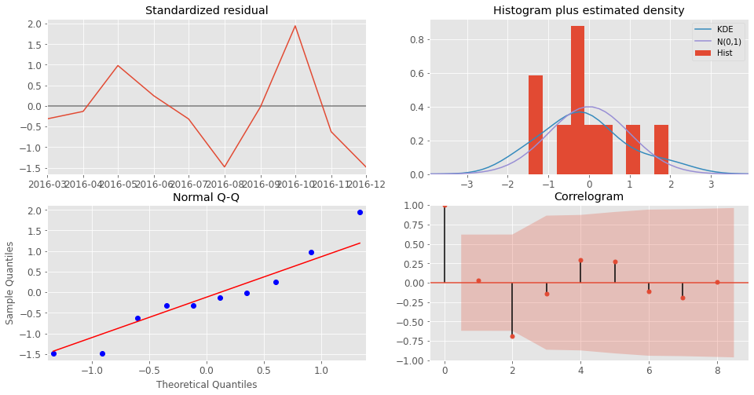

```python
# Model diagnostic
sarima_model_v3_fit.plot_diagnostics(lags = 8, figsize = (16,8))
plt.show()
```

```python
# Predicting
sarima_predict_3 = sarima_model_v3_fit.get_prediction(start = pd.to_datetime('2017-01-01'),
                                                       end = pd.to_datetime('2017-12-01'),
                                                       exog = test_exog_var,
                                                       dynamic = True)
```

```python
# Confidence interval
sarima_predict_conf_3 = sarima_predict_3.conf_int()
sarima_predict_conf_3
```

|  | lower sales | upper sales |
| --- | --- | --- |
| 2017-01-01 | -303.623433 | 1918.199470 |
| 2017-02-01 | 146.953554 | 2368.584195 |
| 2017-03-01 | 125.827903 | 2347.458804 |
| 2017-04-01 | -19.863050 | 2201.767852 |
| 2017-05-01 | 530.188240 | 2751.819144 |
| 2017-06-01 | 3.909651 | 2225.540557 |
| 2017-07-01 | -54.446849 | 2167.184060 |
| 2017-08-01 | -173.363781 | 2048.267130 |
| 2017-09-01 | 243.949714 | 2465.580627 |
| 2017-10-01 | 719.157707 | 2940.788622 |
| 2017-11-01 | 228.701292 | 2450.332209 |
| 2017-12-01 | 320.643062 | 2542.273981 |

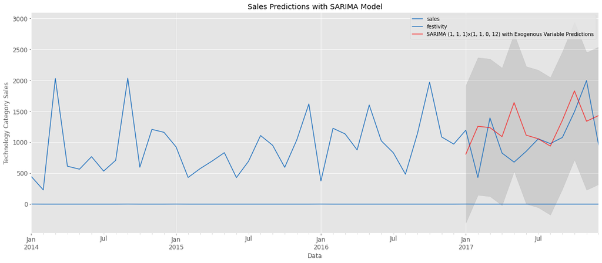

```python
rcParams['figure.figsize'] = 20,8

# Plot observed values
ax = sales_technology_monthly_mean.plot(label = 'Observed Values', color = '#2574BF')

# Plot predicted values
sarima_predict_3.predicted_mean.plot(ax = ax,
                                     label = 'SARIMA (1, 1, 1)x(1, 1, 0, 12) with Exogenous Variable Predictions',
                                     alpha = 0.7,
                                     color = 'red')

# Plot confidence interval
ax.fill_between(sarima_predict_conf_3.index,
                # lower sales
                sarima_predict_conf_3.iloc[:, 0],
                # upper sales
                sarima_predict_conf_3.iloc[:, 1], color = 'k', alpha = 0.1)

# Titles and legends
plt.title('Sales Predictions with SARIMA Model')
plt.xlabel('Data')
plt.ylabel('Technology Category Sales')
plt.legend()
plt.show()
```

```python
# Calculating performance
sarima_results_3 = performance(test_data, sarima_predict_3.predicted_mean)
sarima_results_3
```

```
The prediction MSE is 231232.42
The prediction RMSE is 480.87
The prediction MAPE is 47.99
```

```python
# Ljung-Box test
ljungbox_test = sms.diagnostic.acorr_ljungbox(sarima_model_v3_fit.resid, lags = [30], boxpierce = False)
print('P-value =', ljungbox_test[1])
```

```
P-value = [0.46381394]
```

The p-value is greater than 0.05, which indicates that the residual are independent with a 95% confidence, thefore an (1, 1, 1)x(1, 1, 0, 12) SARIMAX model has a good fit.

Model comparison:

**ARMA (3,1):**

> - The prediction MSE is 168192.9
> - The prediction RMSE is 410.11
> - The prediction MAPE is 28.4

**ARIMA (6,0,4):**

> - The prediction MSE is 120137.97
> - The prediction RMSE is 346.61
> - The prediction MAPE is 20.1

**SARIMA (0,0,1)x(1,1,0,12):**

> - The prediction MSE is 184433.09
> - The prediction RMSE is 429.46
> - The prediction MAPE is 35.35

**SARIMA (1,1,1)x(1,1,0,12):**

> - The prediction MSE is 229093.55
> - The prediction RMSE is 478.64
> - The prediction MAPE is 47.48

**SARIMAX (1,1,1)x(1,1,0,12):**

> - The prediction MSE is 231232.42
> - The prediction RMSE is 480.87
> - The prediction MAPE is 47.99

## Prophet Model

Prophet holiday documentation:

https://facebook.github.io/prophet/docs/seasonality,_holiday_effects,_and_regressors.html

To include holidays and other recurring events into a time series model with Prophet it's necessary to create an additional dataframe to feed the model.

Prophet requires a dataframe with two columns (holiday and ds) and a row for each occurance of the holiday. The dataframe must include all occurances of the holiday, both in the past and in all future dates the model is expected to predict.

It's also possible to include the columns lower_window and upper_window, which extend the holiday to [lower_window, upper_window] days around the date. Essentially a way of indicating extended holidays.

Since this analysis is being conducted on a monthly time series, it doesn't necessarily make sense to include holidays, nevertheless I'm option to include it here as in Prophet's case this variable should not negatively influence the model, plus this could easiy be reverted by emptying the holiday dataframe right before feeding it into the algorithm training process.

Prophet requires that the date column be named 'ds' and the target column be named 'y'

```python
# Load data
data = pd.read_csv('https://raw.githubusercontent.com/dsacademybr/Datasets/master/dataset6.csv')

# Setting column names to lowercase
data.columns = map(str.lower, data.columns)

# Substituting espaces and dashes in the column names by underscores
data.columns = data.columns.str.replace(" ", "_")
data.columns = data.columns.str.replace("-", "_")

# Splitting data by category
df_technology = data.loc[data['category'] == 'Technology']

# Aggregating sales by order date
ts_technology = df_technology.groupby('order_date')['sales'].sum().reset_index()

# Setting the date as index
ts_technology = ts_technology.set_index('order_date')

# Retrieving only sales data
sales_technology = ts_technology[['sales']]

# Changing index type
sales_technology.index = pd.to_datetime(sales_technology.index)

# Resampling data to a monthly frequency
# Done by setting the month as index and then calculating the mean of daily sales over the month
sales_technology_monthly_mean = sales_technology['sales'].resample('MS').mean()

# Train-Test Split
X = sales_technology_monthly_mean
train_size = int(len(X) * 0.75)
trainset, testset = X[0:train_size], X[train_size:]
```

```python
# Dataframe with holidays
holidays_df = pd.DataFrame([])
for date, name in sorted(holidays.UnitedStates(years=[2014,2015,2016,2017]).items()):
    holidays_df = holidays_df.append(pd.DataFrame({'ds': date, 'holiday': name}, index=[0]), ignore_index=True)
holidays_df['ds'] = pd.to_datetime(holidays_df['ds'], format='%Y-%m-%d', errors='ignore')
```

```python
# Creating dataframes for train and test data
df_train = pd.DataFrame({'order_date':trainset.index, 'sales':trainset.values})
df_test = pd.DataFrame({'order_date':testset.index, 'sales':testset.values})
```

```python
# Renaming columns: Prophet requires columns to be names 'ds' and 'y'
df_train = df_train.rename(columns = {'order_date': 'ds', 'sales': 'y'})
df_test = df_test.rename(columns = {'order_date': 'ds', 'sales': 'y'})
```

```python
# Create a Prophet model with annual seasonalisty and the holidays dataframe
prophet_model = Prophet(yearly_seasonality = True, holidays = holidays_df)
```

https://facebook.github.io/prophet/docs/seasonality,_holiday_effects,_and_regressors.html#built-in-country-holidays

Using Prophet's built-in country holiday module, which allows for easy inclusion of holidays into a prophet model for future prediction.

```python
# Adding the built-in Country Holiday method to the model
prophet_model.add_country_holidays(country_name = 'US')
```

```
<fbprophet.forecaster.Prophet at 0x7fb472f27ac8>
```

```python
# Training
prophet_model.fit(df_train)
```

```
INFO:fbprophet:Disabling weekly seasonality. Run prophet with weekly_seasonality=True to override this.
INFO:fbprophet:Disabling daily seasonality. Run prophet with daily_seasonality=True to override this.
```

```
<fbprophet.forecaster.Prophet at 0x7fb472f27ac8>
```

```python
# Creating dataframe to fill with predictions
prophet_predictions_df = prophet_model.make_future_dataframe(periods = 12, freq = 'MS')
prophet_predictions_df.count()
```

```
ds    48
dtype: int64
```

```python
# Forecast
prophet_model_predictions = prophet_model.predict(prophet_predictions_df)
```

```python
# Checking predictions
prophet_model_predictions[['ds', 'yhat', 'yhat_lower', 'yhat_upper']].tail()
```

|  | ds | yhat | yhat_lower | yhat_upper |
| --- | --- | --- | --- | --- |
| 43 | 2017-08-01 | 790.707497 | 499.801894 | 1088.274920 |
| 44 | 2017-09-01 | 1218.777403 | 927.646193 | 1521.812445 |
| 45 | 2017-10-01 | 1566.094812 | 1269.012926 | 1849.231712 |
| 46 | 2017-11-01 | 1315.903621 | 996.833877 | 1607.896813 |
| 47 | 2017-12-01 | 1343.235540 | 1062.111494 | 1669.003815 |

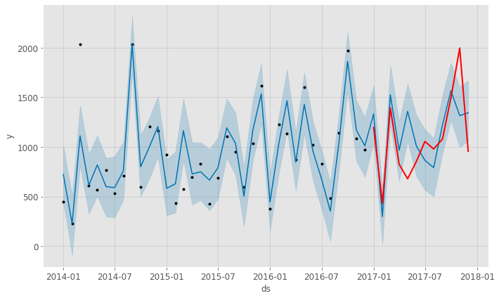

```python
# Creating a plot to visualize predictions

# Plot predictions
fig = prophet_model.plot(prophet_model_predictions)

# Plot actual sales data in red
plt.plot(testset, label = 'Test', color = 'red', linewidth = 2)
plt.show()
```

```python
# Checking the entire output dataframe
prophet_model_predictions.head()
```

|  | ds | trend | yhat_lower | yhat_upper | trend_lower | trend_upper | Christmas Day | Christmas Day_lower | Christmas Day_upper | Christmas Day (Observed) | Christmas Day (Observed)_lower | Christmas Day (Observed)_upper | Columbus Day | Columbus Day_lower | Columbus Day_upper | Independence Day | Independence Day_lower | Independence Day_upper | Independence Day (Observed) | Independence Day (Observed)_lower | Independence Day (Observed)_upper | Labor Day | Labor Day_lower | Labor Day_upper | Martin Luther King, Jr. Day | Martin Luther King, Jr. Day_lower | Martin Luther King, Jr. Day_upper | Memorial Day | Memorial Day_lower | … |
| --- | --- | --- | --- | --- | --- | --- | --- | --- | --- | --- | --- | --- | --- | --- | --- | --- | --- | --- | --- | --- | --- | --- | --- | --- | --- | --- | --- | --- | --- | --- |
| 0 | 2014-01-01 | 925.615137 | 432.789624 | 1012.222619 | 925.615137 | 925.615137 | 0.0 | 0.0 | 0.0 | 0.0 | 0.0 | 0.0 | 0.0 | 0.0 | 0.0 | 0.0 | 0.0 | 0.0 | 0.0 | 0.0 | 0.0 | 0.0 | 0.0 | 0.0 | 0.0 | 0.0 | 0.0 | 0.0 | 0.0 | … |
| 1 | 2014-02-01 | 935.580145 | -90.228342 | 512.658813 | 935.580145 | 935.580145 | 0.0 | 0.0 | 0.0 | 0.0 | 0.0 | 0.0 | 0.0 | 0.0 | 0.0 | 0.0 | 0.0 | 0.0 | 0.0 | 0.0 | 0.0 | 0.0 | 0.0 | 0.0 | 0.0 | 0.0 | 0.0 | 0.0 | 0.0 | … |
| 2 | 2014-03-01 | 944.580797 | 807.834233 | 1419.451660 | 944.580797 | 944.580797 | 0.0 | 0.0 | 0.0 | 0.0 | 0.0 | 0.0 | 0.0 | 0.0 | 0.0 | 0.0 | 0.0 | 0.0 | 0.0 | 0.0 | 0.0 | 0.0 | 0.0 | 0.0 | 0.0 | 0.0 | 0.0 | 0.0 | 0.0 | … |
| 3 | 2014-04-01 | 954.545805 | 323.132499 | 931.465200 | 954.545805 | 954.545805 | 0.0 | 0.0 | 0.0 | 0.0 | 0.0 | 0.0 | 0.0 | 0.0 | 0.0 | 0.0 | 0.0 | 0.0 | 0.0 | 0.0 | 0.0 | 0.0 | 0.0 | 0.0 | 0.0 | 0.0 | 0.0 | 0.0 | 0.0 | … |
| 4 | 2014-05-01 | 964.189361 | 505.974976 | 1116.262684 | 964.189361 | 964.189361 | 0.0 | 0.0 | 0.0 | 0.0 | 0.0 | 0.0 | 0.0 | 0.0 | 0.0 | 0.0 | 0.0 | 0.0 | 0.0 | 0.0 | 0.0 | 0.0 | 0.0 | 0.0 | 0.0 | 0.0 | 0.0 | 0.0 | 0.0 | … |

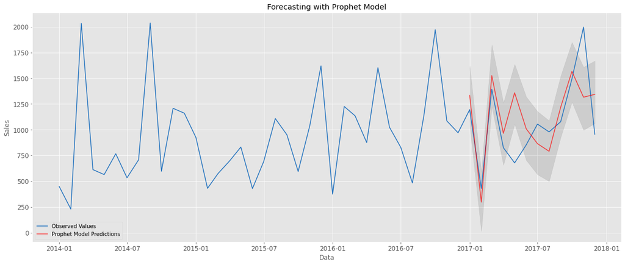

```python
# Plot

# Original series
plt.plot(sales_technology_monthly_mean.index,
         sales_technology_monthly_mean.values,
         label = 'Observed Values',
         color = '#2574BF')

# Predictions
plt.plot(sales_technology_monthly_mean[36:48].index,
         prophet_model_predictions[36:48]['yhat'].values,
         label = 'Prophet Model Predictions',
         alpha = 0.7,
         color = 'red')

# Confidence intervals
plt.fill_between(sales_technology_monthly_mean[36:48].index,
                 prophet_model_predictions[36:48]['yhat_lower'].values,
                 prophet_model_predictions[36:48]['yhat_upper'].values,
                 color = 'k',
                 alpha = 0.1)

plt.title('Forecasting with Prophet Model')
plt.xlabel('Data')
plt.ylabel('Sales')
plt.legend()
plt.show()
```

Using prophet_model_predictions[36:48] since the goal is to predict only the sales for the months with werent used to train the Prophet model - in the case the year 2017.

```python
# Calculating performance
prophet_results = performance(testset.values, prophet_model_predictions[36:48]['yhat'])
prophet_results
```

```
The prediction MSE is 105965.29
The prediction RMSE is 325.52
The prediction MAPE is 26.45
```

Model comparison:

**ARMA (3,1):**

> - The prediction MSE is 168192.9
> - The prediction RMSE is 410.11
> - The prediction MAPE is 28.4

**ARIMA (6,0,4):**

> - The prediction MSE is 120137.97
> - The prediction RMSE is 346.61
> - The prediction MAPE is 20.1

**SARIMA (0,0,1)x(1,1,0,12):**

> - The prediction MSE is 184433.09
> - The prediction RMSE is 429.46
> - The prediction MAPE is 35.35

**SARIMA (1,1,1)x(1,1,0,12):**

> - The prediction MSE is 229093.55
> - The prediction RMSE is 478.64
> - The prediction MAPE is 47.48

**SARIMAX (1,1,1)x(1,1,0,12):**

> - The prediction MSE is 231232.42
> - The prediction RMSE is 480.87
> - The prediction MAPE is 47.99

**Prophet:**

> - The prediction MSE is 105965.29
> - The prediction RMSE is 325.52
> - The prediction MAPE is 26.45

## Part 2: https://colab.research.google.com/drive/10jJOdDusaRTQfSkKTyj3BM2OGVy_CP3N